# ALX-T Project 1

```python
# import pandas
import pandas as pd
```

```python
# read cas
df = pd.read_csv('tmdb-movies.csv')
```

```python
# check csv
df.head()
```

|  | id | imdb_id | popularity | budget | revenue | original_title | cast | homepage | director | tagline | ... | overview | runtime | genres | production_companies | release_date | vote_count | vote_average | release_year | budget_adj | revenue_adj |
| --- | --- | --- | --- | --- | --- | --- | --- | --- | --- | --- | --- | --- | --- | --- | --- | --- | --- | --- | --- | --- | --- |
| 0 | 135397 | tt0369610 | 32.985763 | 150000000 | 1513528810 | Jurassic World | Chris Pratt\|Bryce Dallas Howard\|Irrfan Khan\|Vi... | http://www.jurassicworld.com/ | Colin Trevorrow | The park is open. | ... | Twenty-two years after the events of Jurassic ... | 124 | Action\|Adventure\|Science Fiction\|Thriller | Universal Studios\|Amblin Entertainment\|Legenda... | 6/9/15 | 5562 | 6.5 | 2015 | 1.379999e+08 | 1.392446e+09 |
| 1 | 76341 | tt1392190 | 28.419936 | 150000000 | 378436354 | Mad Max: Fury Road | Tom Hardy\|Charlize Theron\|Hugh Keays-Byrne\|Nic... | http://www.madmaxmovie.com/ | George Miller | What a Lovely Day. | ... | An apocalyptic story set in the furthest reach... | 120 | Action\|Adventure\|Science Fiction\|Thriller | Village Roadshow Pictures\|Kennedy Miller Produ... | 5/13/15 | 6185 | 7.1 | 2015 | 1.379999e+08 | 3.481613e+08 |
| 2 | 262500 | tt2908446 | 13.112507 | 110000000 | 295238201 | Insurgent | Shailene Woodley\|Theo James\|Kate Winslet\|Ansel... | http://www.thedivergentseries.movie/#insurgent | Robert Schwentke | One Choice Can Destroy You | ... | Beatrice Prior must confront her inner demons ... | 119 | Adventure\|Science Fiction\|Thriller | Summit Entertainment\|Mandeville Films\|Red Wago... | 3/18/15 | 2480 | 6.3 | 2015 | 1.012000e+08 | 2.716190e+08 |
| 3 | 140607 | tt2488496 | 11.173104 | 200000000 | 2068178225 | Star Wars: The Force Awakens | Harrison Ford\|Mark Hamill\|Carrie Fisher\|Adam D... | http://www.starwars.com/films/star-wars-episod... | J.J. Abrams | Every generation has a story. | ... | Thirty years after defeating the Galactic Empi... | 136 | Action\|Adventure\|Science Fiction\|Fantasy | Lucasfilm\|Truenorth Productions\|Bad Robot | 12/15/15 | 5292 | 7.5 | 2015 | 1.839999e+08 | 1.902723e+09 |
| 4 | 168259 | tt2820852 | 9.335014 | 190000000 | 1506249360 | Furious 7 | Vin Diesel\|Paul Walker\|Jason Statham\|Michelle ... | http://www.furious7.com/ | James Wan | Vengeance Hits Home | ... | Deckard Shaw seeks revenge against Dominic Tor... | 137 | Action\|Crime\|Thriller | Universal Pictures\|Original Film\|Media Rights ... | 4/1/15 | 2947 | 7.3 | 2015 | 1.747999e+08 | 1.385749e+09 |

5 rows × 21 columns

```python
# check csv shape
df.shape
```

```
(10866, 21)
```

```python
# check csv info
df.info()
```

```
<class 'pandas.core.frame.DataFrame'>
RangeIndex: 10866 entries, 0 to 10865
Data columns (total 21 columns):
 #   Column                Non-Null Count  Dtype
---  ------                --------------  -----
 0   id                    10866 non-null  int64
 1   imdb_id               10856 non-null  object
 2   popularity            10866 non-null  float64
 3   budget                10866 non-null  int64
 4   revenue               10866 non-null  int64
 5   original_title        10866 non-null  object
 6   cast                  10790 non-null  object
 7   homepage              2936 non-null   object
 8   director              10822 non-null  object
 9   tagline               8042 non-null   object
 10  keywords              9373 non-null   object
 11  overview              10862 non-null  object
 12  runtime               10866 non-null  int64
 13  genres                10843 non-null  object
 14  production_companies  9836 non-null   object
 15  release_date          10866 non-null  object
 16  vote_count            10866 non-null  int64
 17  vote_average          10866 non-null  float64
 18  release_year          10866 non-null  int64
 19  budget_adj            10866 non-null  float64
 20  revenue_adj           10866 non-null  float64
dtypes: float64(4), int64(6), object(11)
memory usage: 1.7+ MB
```

```python
# check null values
df.isna().sum()
```

```
id                         0
imdb_id                   10
popularity                 0
budget                     0
revenue                    0
original_title             0
cast                      76
homepage                7930
director                  44
tagline                 2824
keywords                1493
overview                   4
runtime                    0
genres                    23
production_companies    1030
release_date               0
vote_count                 0
vote_average               0
release_year               0
budget_adj                 0
revenue_adj                0
dtype: int64
```

```python
# check duplicated
df.duplicated().sum()
```

```
1
```

```python
# drop duplicated
df.drop_duplicates(inplace=True)
```

### Drop non informative columns

- Id, imdb_id, and homepage do not seem like important column and can be dropped

```python
df.drop(columns=['id', 'imdb_id', 'homepage'], inplace=True)
```

### Fill missing values for text

```python
df['cast'].fillna('Not_Provided', inplace=True)
df['keywords'].fillna('Not_Provided', inplace=True)
df['director'].fillna('Not_Provided', inplace=True)
df['tagline'].fillna('Not_Provided', inplace=True)
df['genres'].fillna('Not_Provided', inplace=True)
df['production_companies'].fillna('Not_Provided', inplace=True)
```

```python
df.isna().sum()
```

```
popularity              0
budget                  0
revenue                 0
original_title          0
cast                    0
director                0
tagline                 0
keywords                0
overview                4
runtime                 0
genres                  0
production_companies    0
release_date            0
vote_count              0
vote_average            0
release_year            0
budget_adj              0
revenue_adj             0
dtype: int64
```

```python
df.head()
```

|  | popularity | budget | revenue | original_title | cast | director | tagline | keywords | overview | runtime | genres | production_companies | release_date | vote_count | vote_average | release_year | budget_adj | revenue_adj |
| --- | --- | --- | --- | --- | --- | --- | --- | --- | --- | --- | --- | --- | --- | --- | --- | --- | --- | --- |
| 0 | 32.985763 | 150000000 | 1513528810 | Jurassic World | Chris Pratt\|Bryce Dallas Howard\|Irrfan Khan\|Vi... | Colin Trevorrow | The park is open. | monster\|dna\|tyrannosaurus rex\|velociraptor\|island | Twenty-two years after the events of Jurassic ... | 124 | Action\|Adventure\|Science Fiction\|Thriller | Universal Studios\|Amblin Entertainment\|Legenda... | 6/9/15 | 5562 | 6.5 | 2015 | 1.379999e+08 | 1.392446e+09 |
| 1 | 28.419936 | 150000000 | 378436354 | Mad Max: Fury Road | Tom Hardy\|Charlize Theron\|Hugh Keays-Byrne\|Nic... | George Miller | What a Lovely Day. | future\|chase\|post-apocalyptic\|dystopia\|australia | An apocalyptic story set in the furthest reach... | 120 | Action\|Adventure\|Science Fiction\|Thriller | Village Roadshow Pictures\|Kennedy Miller Produ... | 5/13/15 | 6185 | 7.1 | 2015 | 1.379999e+08 | 3.481613e+08 |
| 2 | 13.112507 | 110000000 | 295238201 | Insurgent | Shailene Woodley\|Theo James\|Kate Winslet\|Ansel... | Robert Schwentke | One Choice Can Destroy You | based on novel\|revolution\|dystopia\|sequel\|dyst... | Beatrice Prior must confront her inner demons ... | 119 | Adventure\|Science Fiction\|Thriller | Summit Entertainment\|Mandeville Films\|Red Wago... | 3/18/15 | 2480 | 6.3 | 2015 | 1.012000e+08 | 2.716190e+08 |
| 3 | 11.173104 | 200000000 | 2068178225 | Star Wars: The Force Awakens | Harrison Ford\|Mark Hamill\|Carrie Fisher\|Adam D... | J.J. Abrams | Every generation has a story. | android\|spaceship\|jedi\|space opera\|3d | Thirty years after defeating the Galactic Empi... | 136 | Action\|Adventure\|Science Fiction\|Fantasy | Lucasfilm\|Truenorth Productions\|Bad Robot | 12/15/15 | 5292 | 7.5 | 2015 | 1.839999e+08 | 1.902723e+09 |
| 4 | 9.335014 | 190000000 | 1506249360 | Furious 7 | Vin Diesel\|Paul Walker\|Jason Statham\|Michelle ... | James Wan | Vengeance Hits Home | car race\|speed\|revenge\|suspense\|car | Deckard Shaw seeks revenge against Dominic Tor... | 137 | Action\|Crime\|Thriller | Universal Pictures\|Original Film\|Media Rights ... | 4/1/15 | 2947 | 7.3 | 2015 | 1.747999e+08 | 1.385749e+09 |

### Income on movie

```python
df['income'] = df['revenue_adj'] - df['budget_adj']
```

### Correlation plot

```python
import matplotlib.pyplot as plt
import seaborn as sns
%matplotlib inline
```

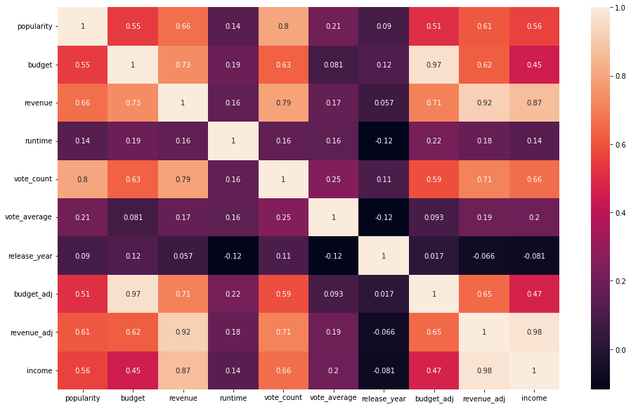

```python
plt.figure(figsize=(16, 10));
sns.heatmap(df.corr(), annot=True);
```

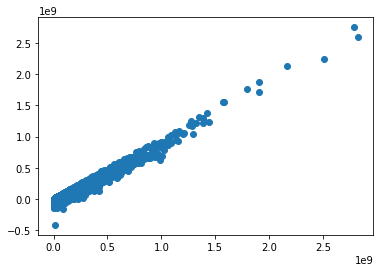

```python
plt.scatter(df['revenue_adj'], df['income']);
```

As shown here, a higher revenue will create a higher income irrespective of other factors Therefore as far as we get a feature that influences revenue, we can assume the same feature will influence income

### The correlation graph shows there is high correlation between revenue and vote_count, popularity and budget

- Let's check this out with other plots

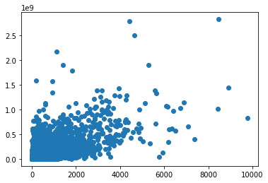

```python
plt.scatter(df['vote_count'], df['revenue_adj']);
```

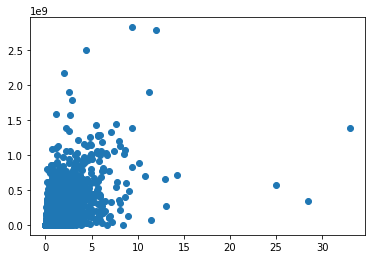

```python
plt.scatter(df['popularity'], df['revenue_adj']);
```

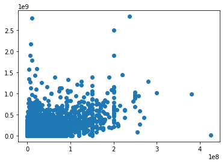

```python
plt.scatter(df['budget'], df['revenue_adj']);
```

Even though these graphs show positive correlation, the correlation are not that consistent, hence there are other factors affecting the revenue

# How does the movie genre affect the income of movie?

## Inspecting movie genre

```python
genre_count = df['genres'].apply(lambda x: len(x.split('|')))
max(genre_count)
```

```
5
```

As show above the maximum genres a movie belongs to is five Now let's see the relation based on number of genres a movie belong to

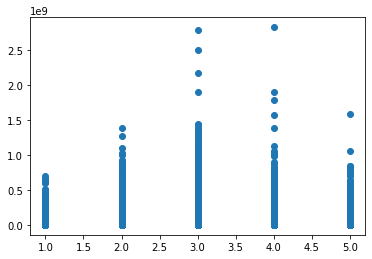

```python
plt.scatter(genre_count, df['revenue_adj']);
```

This shows that movies that belong to 3 or 4 genres tends to bring more revenue that others

```python
# Getting unique genres
genre_list = list(df['genres'].apply(lambda x: x.split('|')))
join_genre = [genre for kgenre in genre_list for genre in kgenre]
len(join_genre), len(set(join_genre))
```

```
(26978, 21)
```

```python
unique_genres = set(join_genre)
unique_genres
```

```
{'Action',
 'Adventure',
 'Animation',
 'Comedy',
 'Crime',
 'Documentary',
 'Drama',
 'Family',
 'Fantasy',
 'Foreign',
 'History',
 'Horror',
 'Music',
 'Mystery',
 'Not_Provided',
 'Romance',
 'Science Fiction',
 'TV Movie',
 'Thriller',
 'War',
 'Western'}
```

```python
### Let's check the correlation between each movie genre and income
[{genre: df['revenue_adj'].corr(df['genres'].apply(lambda x: genre in x.split('|')))} for genre in unique_genres]
```

```
[{'Comedy': -0.017580719122810957},
 {'Fantasy': 0.12559393596977353},
 {'Foreign': -0.04549238550203623},
 {'Music': -0.006436771468450617},
 {'History': -0.004211668471912443},
 {'Animation': 0.061437684657103725},
 {'Science Fiction': 0.0879283620050641},
 {'Crime': 0.013741362874031578},
 {'Adventure': 0.24707871354596794},
 {'Romance': -0.009475429228427713},
 {'Mystery': -0.0009413757017258377},
 {'Thriller': 0.01636897298473942},
 {'Drama': -0.06686290533480865},
 {'Horror': -0.07946056236134062},
 {'Action': 0.14805810109889567},
 {'Documentary': -0.07612896661208822},
 {'TV Movie': -0.044073605343740926},
 {'Not_Provided': -0.016358629693386417},
 {'Family': 0.08988313690022014},
 {'Western': -0.004522835310198916},
 {'War': 0.0205485065724823}]
```

```python
df.sort_values(by='revenue_adj', ascending=False)[:2]
```

|  | popularity | budget | revenue | original_title | cast | director | tagline | keywords | overview | runtime | genres | production_companies | release_date | vote_count | vote_average | release_year | budget_adj | revenue_adj | income |
| --- | --- | --- | --- | --- | --- | --- | --- | --- | --- | --- | --- | --- | --- | --- | --- | --- | --- | --- | --- |
| 1386 | 9.432768 | 237000000 | 2781505847 | Avatar | Sam Worthington\|Zoe Saldana\|Sigourney Weaver\|S... | James Cameron | Enter the World of Pandora. | culture clash\|future\|space war\|space colony\|so... | In the 22nd century, a paraplegic Marine is di... | 162 | Action\|Adventure\|Fantasy\|Science Fiction | Ingenious Film Partners\|Twentieth Century Fox ... | 12/10/09 | 8458 | 7.1 | 2009 | 2.408869e+08 | 2.827124e+09 | 2.586237e+09 |
| 1329 | 12.037933 | 11000000 | 775398007 | Star Wars | Mark Hamill\|Harrison Ford\|Carrie Fisher\|Peter ... | George Lucas | A long time ago in a galaxy far, far away... | android\|galaxy\|hermit\|death star\|lightsaber | Princess Leia is captured and held hostage by ... | 121 | Adventure\|Action\|Science Fiction | Lucasfilm\|Twentieth Century Fox Film Corporation | 3/20/77 | 4428 | 7.9 | 1977 | 3.957559e+07 | 2.789712e+09 | 2.750137e+09 |

```python
genre_df = df.copy()
for genre in unique_genres:
    genre_df[f'genre_{genre}'] = df['genres'].apply(lambda x: genre in x.split('|'))
```

```python
genre_df.columns
```

```
Index(['popularity', 'budget', 'revenue', 'original_title', 'cast', 'director',
       'tagline', 'keywords', 'overview', 'runtime', 'genres',
       'production_companies', 'release_date', 'vote_count', 'vote_average',
       'release_year', 'budget_adj', 'revenue_adj', 'income', 'genre_Comedy',
       'genre_Fantasy', 'genre_Foreign', 'genre_Music', 'genre_History',
       'genre_Animation', 'genre_Science Fiction', 'genre_Crime',
       'genre_Adventure', 'genre_Romance', 'genre_Mystery', 'genre_Thriller',
       'genre_Drama', 'genre_Horror', 'genre_Action', 'genre_Documentary',
       'genre_TV Movie', 'genre_Not_Provided', 'genre_Family', 'genre_Western',
       'genre_War'],
      dtype='object')
```

```python
genre_df['income'].mean(), max(genre_df['income'])
```

```
(33819107.72152208, 2750136650.919176)
```

```python
genres_col = ['genre_Not_Provided', 'genre_Action', 'genre_War', 'genre_Western',
       'genre_Horror', 'genre_Music', 'genre_Romance', 'genre_Documentary',
       'genre_Comedy', 'genre_Science Fiction', 'genre_Thriller',
       'genre_History', 'genre_Animation', 'genre_Drama', 'genre_TV Movie',
       'genre_Adventure', 'genre_Foreign', 'genre_Mystery', 'genre_Fantasy',
       'genre_Crime', 'genre_Family']
```

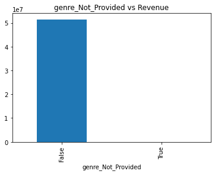

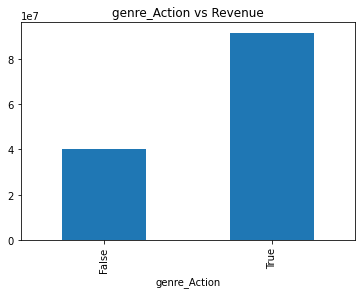

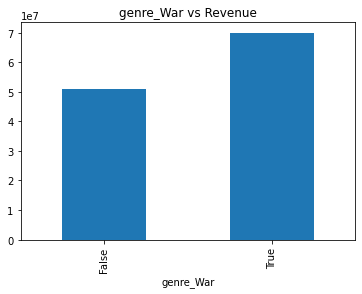

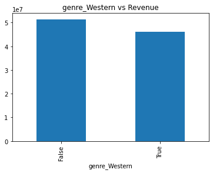

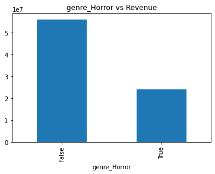

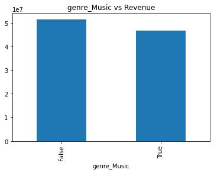

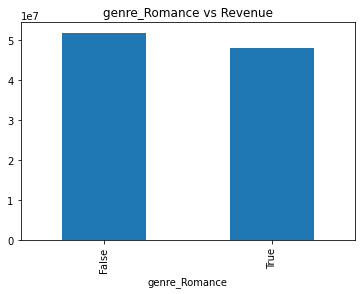

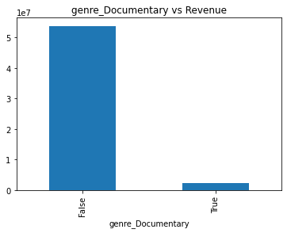

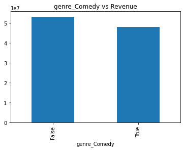

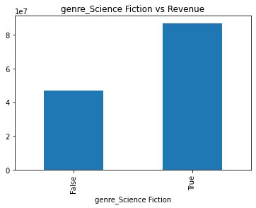

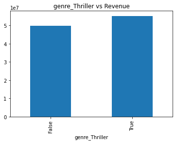

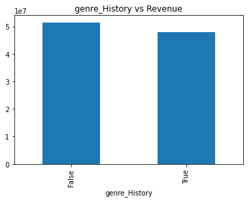

[9 more figures not shown]

```python
# fig, ax = plt.subplots(len(genres_col))
# plt.figure(figsize=(16, 10));
for genre in genres_col:
    genre_df.groupby(genre)['revenue_adj'].mean().plot(kind='bar')
    plt.title(f'{genre} vs Revenue')
    plt.show()
```

### As shown above, movies in the following genre generate more revenue

- Action
- Science Fiction
- Animation
- Adventure
- Fantasy
- Family

### While movies in the following genre tend to generate lesser revenue

- Horror
- Documentary
- Drama
- TV Movie
- Foreign

# How does the movie directors affect the income of movies?

## Inspecting movie directors

```python
max(df['director'].apply(lambda x: len(x.split('|'))))
```

```
36
```

```python
director_list = list(df['director'].apply(lambda x: x.split('|')))
join_director = [dirc for kdirc in director_list for dirc in kdirc]
len(join_director), len(set(join_director))
```

```
(11935, 5363)
```

```python
unique_directors = set(join_director)
```

```python
directors_df = df.copy()
for director in unique_directors:
    directors_df[f'director_{director}'] = df['director'].apply(lambda x: director in x.split('|'))
```

```python
directors_df.columns
```

```
Index(['popularity', 'budget', 'revenue', 'original_title', 'cast', 'director',
       'tagline', 'keywords', 'overview', 'runtime',
       ...
       'director_Graham Annable', 'director_Andrews Jenkins',
       'director_Craig Shapiro', 'director_Keith Fulton',
       'director_Nathan H. Juran', 'director_Shane Van Dyke',
       'director_Rob Bowman', 'director_Jerry Lewis',
       'director_Michael LaBash', 'director_Joe Dante'],
      dtype='object', length=5382)
```

```python
director_cols = [col for col in directors_df.columns if col.startswith('director_')]
```

```python
director_cols[:2]
```

```
['director_Peter Howitt', 'director_Luke Moran']
```

```python
df['revenue_adj'].mean()
```

```
51369001.75884263
```

```python
top_directors = {}
for director in director_cols:
    if directors_df.groupby(director)['director'].count()[1] > 10:
        if directors_df.groupby(director)['revenue_adj'].mean()[1] > df['revenue_adj'].mean():
            top_directors[director.split('_')[1]] = directors_df.groupby(director)['revenue_adj'].mean()[1]
```

```python
{k: v for k, v in sorted(top_directors.items(), key=lambda item: item[1], reverse=True)}
```

```
{'James Cameron': 666110987.1263167,
 'Steven Spielberg': 508897467.89766926,
 'Peter Jackson': 501417701.1770545,
 'Michael Bay': 496424723.4763687,
 'Roland Emmerich': 370634635.77061605,
 'Chris Columbus': 363862659.0028005,
 'Robert Zemeckis': 332685191.1363859,
 'Sam Raimi': 256841560.25965852,
 'John Lasseter': 243764619.4366947,
 'Tim Burton': 233007059.08422202,
 'Richard Donner': 209632480.76296523,
 'Shawn Levy': 208618236.3664966,
 'Ron Howard': 205777067.35384226,
 'William Friedkin': 204039890.92568192,
 'Tony Scott': 197278394.59782138,
 'Jay Roach': 188971895.16594222,
 'Ridley Scott': 183459390.3609846,
 'Brett Ratner': 181072794.44680682,
 'Ivan Reitman': 177687204.03499752,
 'Mike Newell': 163038250.08697006,
 'Garry Marshall': 150414373.32884625,
 'Sydney Pollack': 140292855.6042467,
 'Francis Ford Coppola': 140245712.6684899,
 'Peter Farrelly': 140239991.53228486,
 'Quentin Tarantino': 134946221.7455444,
 'Dennis Dugan': 131059853.05567895,
 'Bobby Farrelly': 129907841.23933159,
 'Phillip Noyce': 118434244.87246029,
 'Michael Mann': 115499243.7561978,
 'John G. Avildsen': 112869588.60638843,
 'Mel Brooks': 111346019.92891611,
 'Oliver Stone': 108577010.13782084,
 'Peter Weir': 108246249.86099048,
 'Clint Eastwood': 107637917.71944207,
 'Steven Soderbergh': 107620595.77412255,
 'Mike Nichols': 107222345.61614037,
 'John Landis': 105419088.58224392,
 'Joel Schumacher': 99758450.06614701,
 'Barry Levinson': 99731420.32209665,
 'John Badham': 94317316.24326842,
 'Renny Harlin': 88103971.65756747,
 'Michael Apted': 83325421.42551121,
 'Brian De Palma': 82479380.46982405,
 'Roger Donaldson': 78958333.95152815,
 'Martin Scorsese': 78275547.78913955,
 'Rob Reiner': 76407965.68494922,
 'Danny Boyle': 68289828.60747741,
 'Robert Rodriguez': 67782466.18074632,
 'Lasse HallstrÃ¶m': 67155757.45994583,
 'Joel Coen': 64065374.834952846,
 'Wes Craven': 62149490.40605751,
 'Don Bluth': 62035971.95731709,
 'Curtis Hanson': 60702265.48296328,
 'Stephen Herek': 58578373.67181606,
 'Joe Dante': 57214982.212823056,
 'Blake Edwards': 54485756.40885381}
```

### As displayed above, after comparing directors with more than 10 movies, we can see that the following director's movies have higher revenue

- James Cameron
- Steven Spielberg
- Peter Jackson
- Michael Bay
- Roland Emmerich

# How does the movie cast affect the income of movies?

## Inspecting movies cast

```python
max(df['cast'].apply(lambda x: len(x.split('|'))))
```

```
5
```

```python
cast_list = list(df['cast'].apply(lambda x: x.split('|')))
join_cast = [cast for kcast in cast_list for cast in kcast]
len(join_cast), len(set(join_cast))
```

```
(52644, 19027)
```

```python
unique_casts = set(join_cast)
```

```python
cast_df = df.copy()
for cast in unique_casts:
    cast_df[f'cast_{cast}'] = df['cast'].apply(lambda x: cast in x.split('|'))
```

```python
len(cast_df.columns)
```

```
19046
```

```python
cast_cols = [col for col in cast_df.columns if col.startswith('cast_')]
```

```python
cast_cols[:2]
```

```
['cast_Leigh-Allyn Baker', 'cast_Grace Zabriskie']
```

```python
top_casts = {}
for cast in cast_cols:
    if cast_df.groupby(cast)['cast'].count()[1] > 10:
        if cast_df.groupby(cast)['revenue_adj'].mean()[1] > df['revenue_adj'].mean():
            top_casts[cast.split('_')[1]] = cast_df.groupby(cast)['revenue_adj'].mean()[1]
```

```python
{k: v for k, v in sorted(top_casts.items(), key=lambda item: item[1], reverse=True)}
```

```
{'Emma Watson': 629024100.1111324,
 'Carrie Fisher': 591172903.9699365,
 'Daniel Radcliffe': 532192639.68366516,
 'Rupert Grint': 522399381.3597659,
 'Orlando Bloom': 439699391.4910922,
 'Mark Hamill': 411023763.7175235,
 'Ian McKellen': 394151036.045409,
 'Julie Andrews': 374920252.9346237,
 'Will Smith': 353438302.0548761,
 'Harrison Ford': 349606741.5644566,
 'Michelle Rodriguez': 320086844.6738206,
 'Chris Hemsworth': 314587303.36889136,
 'Roger Moore': 304423359.17647356,
 'Tom Cruise': 303048655.2223476,
 'Denis Leary': 284759722.74190646,
 'Sam Worthington': 268302737.68105885,
 'Joe Pesci': 253400048.05044428,
 'Liam Hemsworth': 252191515.57385242,
 'Tyrese Gibson': 251855022.6810418,
 'Mike Myers': 247424931.38590723,
 'Dwayne Johnson': 242530406.36068287,
 'Liv Tyler': 241552334.61998186,
 'Leonardo DiCaprio': 241101094.77634266,
 'Peter Facinelli': 239235862.31903684,
 'Frances Fisher': 237893951.5429203,
 'Bonnie Hunt': 237188488.57365677,
 'Anne Hathaway': 235831680.82879946,
 'Zoe Saldana': 235346607.79860517,
 'Vin Diesel': 234523259.99751827,
 'Tom Hanks': 232008372.939564,
 'Shia LaBeouf': 231891771.7206552,
 'Roy Scheider': 231234351.84408003,
 'Jennifer Lawrence': 226045059.96625644,
 'Natalie Portman': 217945428.1190522,
 'Ralph Fiennes': 216998439.08708778,
 'Richard Dreyfuss': 216524178.29270336,
 'Chris Evans': 216228774.4015189,
 'Tobey Maguire': 215800185.10779703,
 'Billy Zane': 214450589.53113493,
 'Robert Pattinson': 213935490.4864895,
```

[output cut: 532 more lines]

```
 'Tim Robbins': 53263467.466465116,
 'Charlton Heston': 53059209.434534945,
 'Anthony Quinn': 53002717.84822139,
 'Liev Schreiber': 52838973.95824365,
 'Dakota Fanning': 52685874.81186104,
 'Mekhi Phifer': 52514628.79478446,
 'Matt Dillon': 52475731.50115403,
 'Uma Thurman': 52303297.835001566,
 'James Woods': 51897868.00496186,
 'Patrick Wilson': 51810462.27394835,
 'Mary Elizabeth Winstead': 51675206.77931345,
 'D. B. Sweeney': 51538058.773222275,
 'Ron Perlman': 51532924.27114524,
 'J.K. Simmons': 51458012.5201547,
 'Rob Corddry': 51415226.37833514}
```

- Emma Watson
- Carrie Fisher
- Daniel Radcliffe
- Rupert Grint
- Orlando Bloom

# How does the movie production company affect the income of movies

## Inspecting production company

```python
max(df['production_companies'].apply(lambda x: len(x.split('|'))))
```

```
5
```

```python
comp_list = list(df['production_companies'].apply(lambda x: x.split('|')))
join_comp = [comp for kcomp in comp_list for comp in kcomp]
len(join_comp), len(set(join_comp))
```

```
(24255, 7880)
```

```python
unique_comps = set(join_comp)
```

```python
comp_df = df.copy()
for comp in unique_comps:
    comp_df[f'comp_{comp}'] = df['production_companies'].apply(lambda x: comp in x.split('|'))
```

```python
len(cast_df.columns)
```

```
19046
```

```python
comp_cols = [col for col in comp_df.columns if col.startswith('comp_')]
```

```python
comp_cols[:2]
```

```
['comp_Shogakukan Production', 'comp_2 Loop Films']
```

```python
top_comps = {}
for comp in comp_cols:
    if comp_df.groupby(comp)['production_companies'].count()[1] > 10:
        if comp_df.groupby(comp)['revenue_adj'].mean()[1] > df['revenue_adj'].mean():
            top_comps[comp.split('_')[1]] = comp_df.groupby(comp)['revenue_adj'].mean()[1]
```

```python
{k: v for k, v in sorted(top_comps.items(), key=lambda item: item[1], reverse=True)}
```

```
{'Lucasfilm': 683781553.8809587,
 'Heyday Films': 564160074.2570236,
 'Eon Productions': 555883175.3460546,
 'WingNut Films': 506312195.82732993,
 'Twentieth Century Fox Animation': 420936048.2527366,
 'Dentsu': 377659885.96461207,
 'Moving Picture Company (MPC)': 375340899.722523,
 'Jerry Bruckheimer Films': 365223415.4644242,
 'Marvel Enterprises': 344102783.9636606,
 'Sunswept Entertainment': 339232101.5383791,
 'Amblin Entertainment': 327680690.0628984,
 '1492 Pictures': 324660215.5373108,
 'Skydance Productions': 323197480.78794664,
 'Walt Disney Feature Animation': 322026350.7788067,
 'Blue Sky Studios': 307140685.2957337,
 'Legendary Pictures': 301904212.5733245,
 'Marvel Studios': 298695862.0037244,
 'Temple Hill Entertainment': 296089937.61657745,
 'DreamWorks Animation': 266677518.03659302,
 'Cruise/Wagner Productions': 258953419.25634634,
 'TSG Entertainment': 254232516.34528637,
 'Overbrook Entertainment': 252540938.67052373,
 'Illumination Entertainment': 252167081.49619976,
 "Donners' Company": 247918035.1857083,
 'Tim Burton Productions': 246868467.48669103,
 'Di Bonaventura Pictures': 237437383.26180995,
 'Ingenious Film Partners': 232435845.9612517,
 'Walt Disney': 215848159.4298044,
 'Media Rights Capital': 215557092.28496948,
 'Dune Entertainment': 211256913.04521045,
 'Original Film': 209419512.41662988,
 'Platinum Dunes': 202581629.93946698,
 '21 Laps Entertainment': 201896992.8337514,
 'Pixar Animation Studios': 200336098.62420768,
 'Bad Hat Harry Productions': 199021461.4601013,
 'DreamWorks SKG': 193364510.0844472,
 'Ingenious Media': 188705557.49024427,
 'Twentieth Century Fox Film Corporation': 185274060.52682373,
 'Walt Disney Animation Studios': 178314687.65128508,
 'Hughes Entertainment': 176927267.1432715,
```

[output cut: 93 more lines]

```
 'DC Comics': 58755555.99833364,
 'Robert Simonds Productions': 58186218.80660531,
 'Dino De Laurentiis Company': 57659111.95998984,
 'Castle Rock Entertainment': 56313422.91411582,
 'Canal+': 56272564.09161673,
 'DNA Films': 55831782.74858794,
 'Newmarket Capital Group': 55260513.922685914,
 '20th Century Fox': 54490428.12557265,
 'Morgan Creek Productions': 53793283.5182783,
 'Scion Films': 53482200.79580442,
 'American Zoetrope': 52814704.48488355,
 'Dimension Films': 52801611.39896643,
 'Orion Pictures': 51626826.9207575,
 'Focus Features': 51553442.21152117,
 'Epsilon Motion Pictures': 51503481.21899163}
```

### As displayed above, after comparing companies with more than 10 movies, we can see that the following company's movies have higher revenue

- Lucasfilm
- Heyday Films
- Eon Productions
- WingNut Films
- Twentieth Century Fox Animation